# Esportazioni di prodotti italiani nel mondo

Questo progetto ha lo scopo di rappresentare graficamente l’andamento che ha subito il fatturato italiano per l’esportazione di prodotti nel mondo tra il 1994 e il 2019.

```r
#LIBRERIE UTILIZZATE

library(tidyr)
library (dplyr)
library(ggplot2)
library(graphics)
library(modelr)
library(purrr)
```

Inizialmente è necessario importare il dataset attraverso il comando **read.cvs**.

In seguito è possibile assegnare al dataset una nuova variabile.

```r
export = read.csv("Export ($ thousand) 1994-2019.csv", header = TRUE, sep = ";")
```

Il dataset, inoltre, deve essere modificato in modo che si possano avere soltanto i dati che più interessano per la creazione dei grafici. Quindi, attravarso **select** (dplyr) vengono selezionate le colonne e con **pivot_longer** (tidyr) le colonne preesistenti vengono convertite in righe.

```r
tab1 <- select(export, Reporter.Name, Partner.Name, Product.Group, (X1994 : X2019))

tab1 <- pivot_longer( tab1,
                      c('X1994':'X2019'),
                      names_prefix = "X",
                      names_to = "Year",
                      values_to = "Export"
                     )
```

Ora è possibile rappresentare graficamente l’andamento generale delle esportazioni italiane, dove ogni riga rappresenta un Paese importatore. In questo modo, dal grafico riportato di seguito, è possibile notare un andamento non regolare nel tempo e non simile per tutti gli Stati presi in considerazione.  
Questa rappresentazione grafica non aiuta, però, a capire chiaramente nel dettaglio come la situazione si è sviluppata nel corso degli anni.

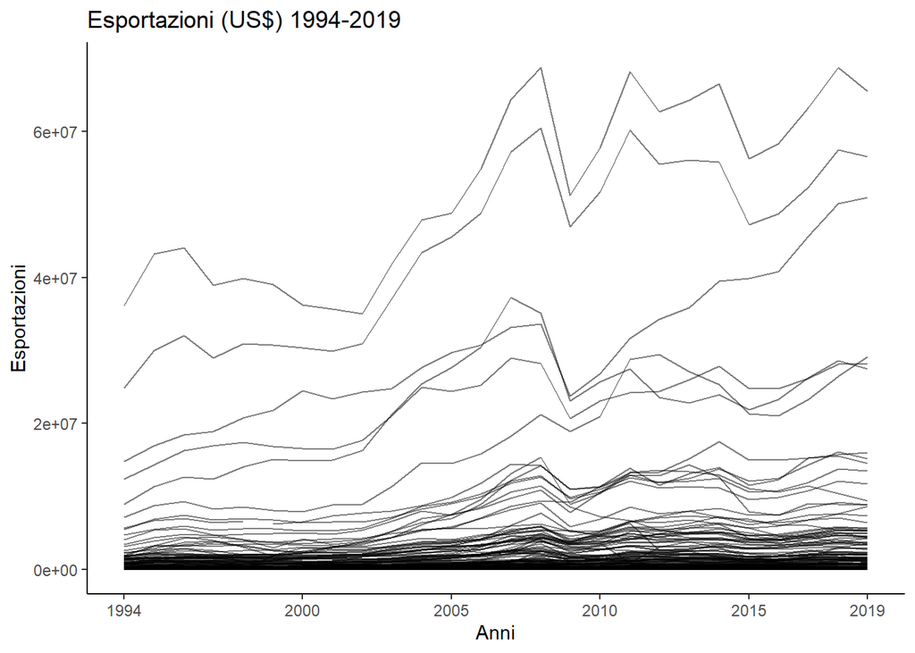

```r
ggplot(tab1, aes(x = as.numeric(Year), y = as.numeric(sub(",", ".", Export, fixed = TRUE)))) +
  geom_line(aes(group = Partner.Name), alpha = 1/2) +
  theme_classic() +
  xlab("Anni") +
  ylab("Esportazioni") +
  scale_x_continuous(breaks = c(1994, 2000, 2005, 2010, 2015, 2019),
                     limits = c(1994, 2019)) +
  ggtitle("Esportazioni (US$) 1994-2019")
```

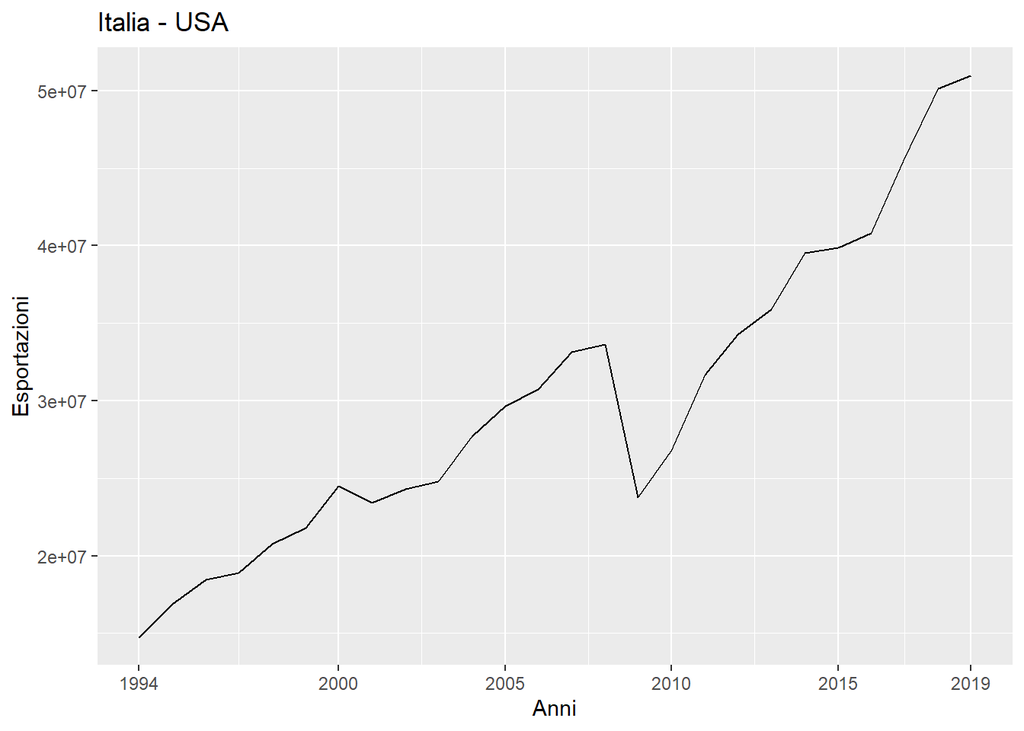

```r
us_exp <- filter(tab1, Partner.Name == "United States")

us_exp %>%
ggplot(aes(x = as.numeric(Year), y = as.numeric(sub(",", ".", Export, fixed = TRUE)))) +
  geom_line() +
  xlab("Anni") +
  ylab("Esportazioni") +
  scale_x_continuous(breaks = c(1994, 2000, 2005, 2010, 2015, 2019),
                     limits = c(1994, 2019)) +
  ggtitle("Italia - USA")
```

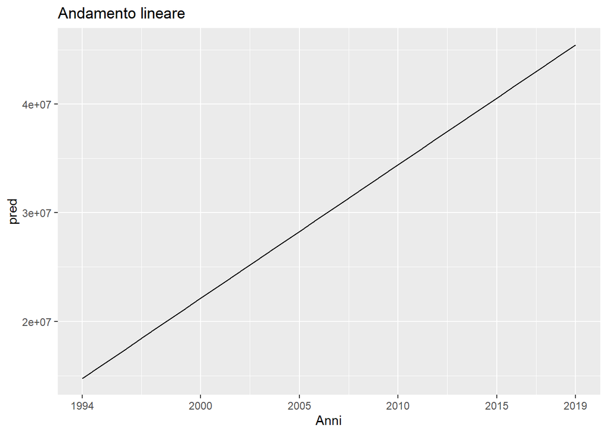

```r
us_exp_lt <- lm((as.numeric(sub(",", ".", Export, fixed = TRUE))) ~ (as.numeric(Year)), data = us_exp)

us_exp %>%
  add_predictions(us_exp_lt) %>%
  ggplot(aes((as.numeric(Year)), pred)) +
  geom_line() +
  xlab("Anni") +
  scale_x_continuous(breaks = c(1994, 2000, 2005, 2010, 2015, 2019),
                     limits = c(1994, 2019)) +
  ggtitle("Andamento lineare")
```

Ora vengono calcolati i resuidi sul Paese appena considerato per poi adattare la formula a tutti gli altri Stati.

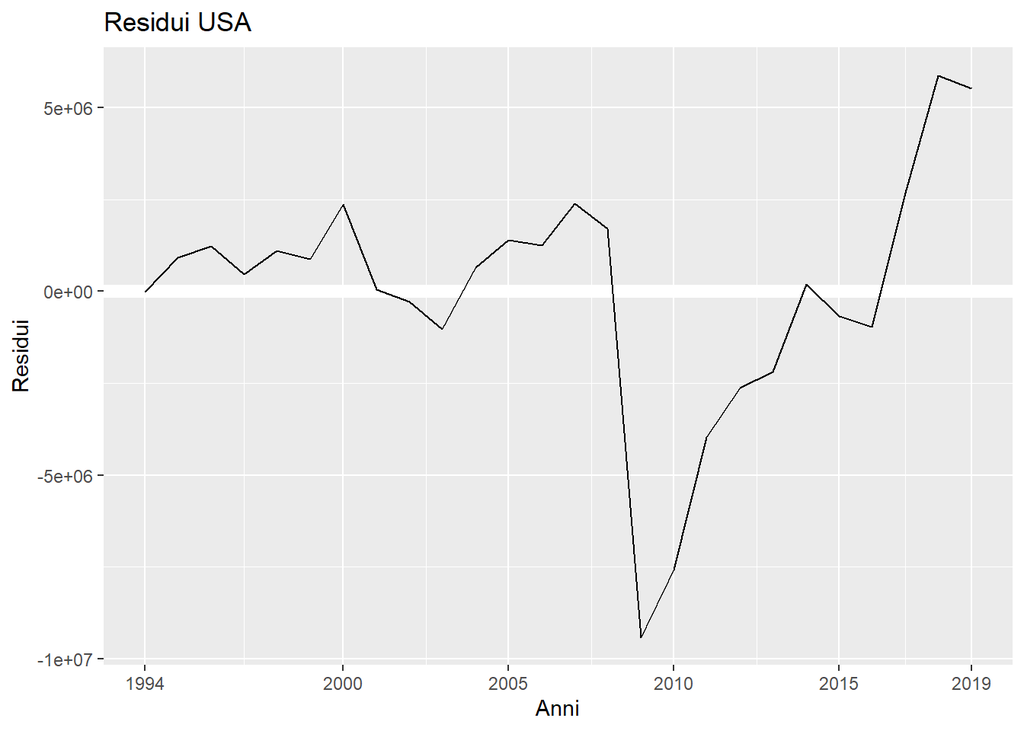

```r
#RESIDUI

us_exp %>%
  add_residuals(us_exp_lt) %>%
  ggplot(aes((as.numeric(Year)), resid)) +
  geom_hline(yintercept = 0, colour = "white", size = 3) +
  geom_line() +
  xlab("Anni") +
  ylab("Residui") +
  scale_x_continuous(breaks = c(1994, 2000, 2005, 2010, 2015, 2019),
                     limits = c(1994, 2019)) +
  ggtitle("Residui USA")
```

Attraverso la funzione **nest()** (tidyr) vengono annidati i dati creando un dataset per ciascun Paese.

```r
by_partner_name <- tab1 %>%
  group_by(Partner.Name) %>%
  nest()
```

```r
partner_name_model <- function(df) {
  lm((as.numeric(sub(",", ".", Export, fixed = TRUE))) ~ (as.numeric(Year)), data = df)
}
```

```r
by_partner_name <- by_partner_name %>%
  mutate(model = map(data, partner_name_model))
by_partner_name
```

```
## # A tibble: 245 x 3
## # Groups:   Partner.Name [245]
##    Partner.Name        data              model
##    <chr>               <list>            <list>
##  1 Afghanistan         <tibble [26 x 4]> <lm>
##  2 Albania             <tibble [26 x 4]> <lm>
##  3 Algeria             <tibble [26 x 4]> <lm>
##  4 American Samoa      <tibble [26 x 4]> <lm>
##  5 Andorra             <tibble [26 x 4]> <lm>
##  6 Angola              <tibble [26 x 4]> <lm>
##  7 Anguila             <tibble [26 x 4]> <lm>
##  8 Antarctica          <tibble [26 x 4]> <lm>
##  9 Antigua and Barbuda <tibble [26 x 4]> <lm>
## 10 Argentina           <tibble [26 x 4]> <lm>
## # ... with 235 more rows
```

```r
#by_partner_name$model[[1]]
```

Ora per calcolare i residui di ogni Paese si utilizza **add_residual** (modelr) e **map2** (purrr).

```r
by_partner_name <- by_partner_name %>%
  mutate(data = map2(data, model, add_residuals))
by_partner_name
```

```
## # A tibble: 245 x 3
## # Groups:   Partner.Name [245]
##    Partner.Name        data              model
##    <chr>               <list>            <list>
##  1 Afghanistan         <tibble [26 x 5]> <lm>
##  2 Albania             <tibble [26 x 5]> <lm>
##  3 Algeria             <tibble [26 x 5]> <lm>
##  4 American Samoa      <tibble [26 x 5]> <lm>
##  5 Andorra             <tibble [26 x 5]> <lm>
##  6 Angola              <tibble [26 x 5]> <lm>
##  7 Anguila             <tibble [26 x 5]> <lm>
##  8 Antarctica          <tibble [26 x 5]> <lm>
##  9 Antigua and Barbuda <tibble [26 x 5]> <lm>
## 10 Argentina           <tibble [26 x 5]> <lm>
## # ... with 235 more rows
```

```r
#by_partner_name$data[[1]]
```

```r
(resids = unnest(by_partner_name, data))
```

```
## # A tibble: 6,370 x 7
## # Groups:   Partner.Name [245]
##    Partner.Name Reporter.Name Product.Group    Year  Export     resid model
##    <chr>        <chr>         <chr>            <chr> <chr>      <dbl> <list>
##  1 Afghanistan  Italy         "  All Products" 1994  1835,093  -3123. <lm>
##  2 Afghanistan  Italy         "  All Products" 1995  1659,508  -4200. <lm>
##  3 Afghanistan  Italy         "  All Products" 1996  2790,5    -3971. <lm>
##  4 Afghanistan  Italy         "  All Products" 1997  1152,369  -6511. <lm>
##  5 Afghanistan  Italy         "  All Products" 1998  914,189   -7651. <lm>
##  6 Afghanistan  Italy         "  All Products" 1999  1164,722  -8303. <lm>
##  7 Afghanistan  Italy         "  All Products" 2000  1053,252  -9316. <lm>
##  8 Afghanistan  Italy         "  All Products" 2001  1332,487  -9939. <lm>
##  9 Afghanistan  Italy         "  All Products" 2002  7327,681  -4845. <lm>
## 10 Afghanistan  Italy         "  All Products" 2003  19757,218  6682. <lm>
## # ... with 6,360 more rows
```

Ora è possibile creare un grafico nel quale vegono tracciati i residui.

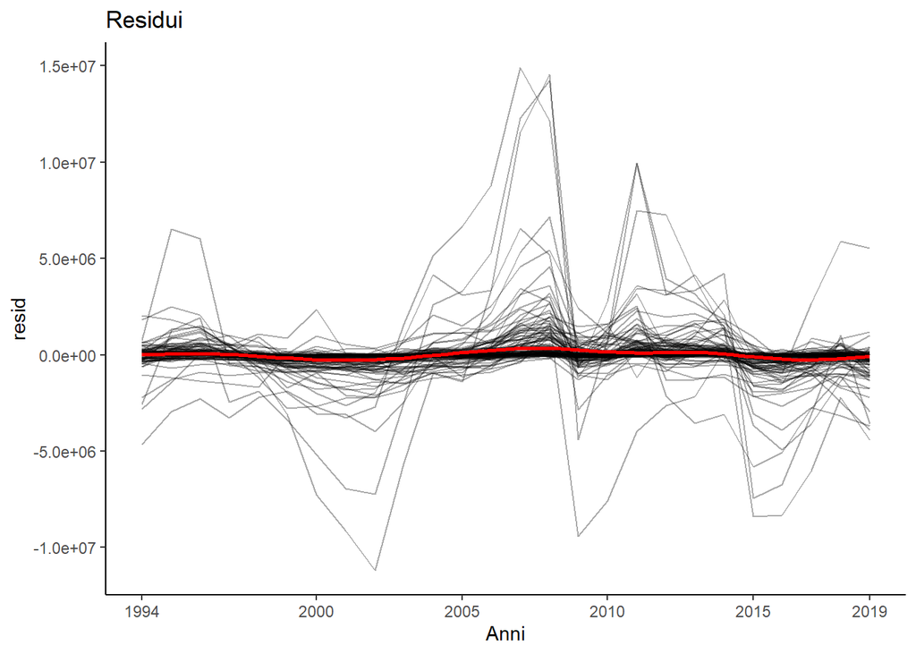

```r
resids %>%
  ggplot(aes((as.numeric(Year)), resid)) +
  geom_line(aes(group = Partner.Name), alpha = 1 / 3) +
  geom_smooth(se = FALSE, color = "red") +
  theme_classic() +
  xlab("Anni") +
  scale_x_continuous(breaks = c(1994, 2000, 2005, 2010, 2015, 2019),
                     limits = c(1994, 2019)) +
  ggtitle("Residui")
```

Dal grafico si può notare che l’Italia in alcuni Stati ha esportato meno prodotti rispetto che in altri. Per capire come si è evoluta nel tempo la situazione per questi ultimi applichiamo **filter** (dplyr).

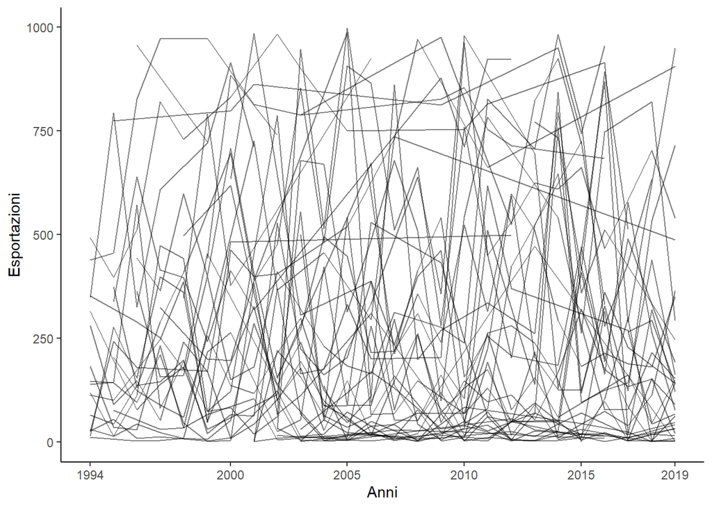

```r
tab2 <- filter(tab1, (as.numeric(sub(",", ".", Export, fixed = TRUE))) <= 1000)

ggplot(tab2,
       aes(x = as.numeric(Year), y = as.numeric(sub(",", ".", Export, fixed = TRUE)))) +
  geom_line(aes(group = Partner.Name), alpha = 1/2) +
  theme_classic() +
  xlab("Anni") +
  ylab("Esportazioni") +
  scale_x_continuous(breaks = c(1994, 2000, 2005, 2010, 2015, 2019),
                     limits = c(1994, 2019))
```

Inoltre, per analizzare in maniera più dettagliata il grafico vengono selezionate le righe riguardanti alcuni Stati europei come il Regno Unito e la Spagna. Dal grafico si nota che nel 2008 circa c’è una rilevante diminuzione di esportazioni, dovuto alla crisi finanziaria iniziata nel 2006 negli Stati Uniti e che ha avuto ripercussioni sul continente Europeo.

```r
tab3 <- tab1 %>%
          filter(Partner.Name == "United Kingdom")
```

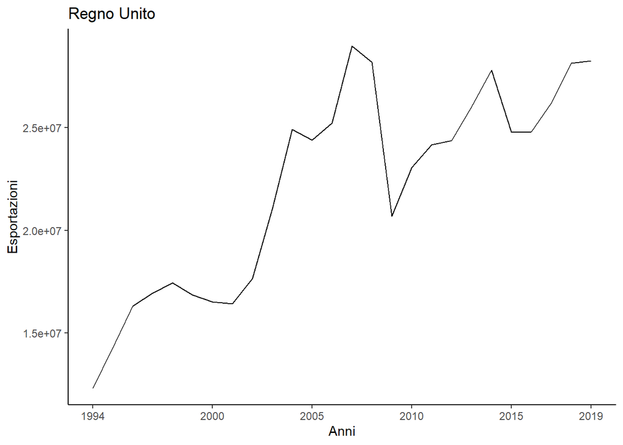

```r
ggplot(tab3, aes(x = as.numeric(Year), y = as.numeric(sub(",", ".", Export, fixed = TRUE)))) +
  geom_line(aes(group = Partner.Name), alpha = 1) +
  theme_classic() +
  xlab("Anni") +
  ylab("Esportazioni") +
  scale_x_continuous(breaks = c(1994, 2000, 2005, 2010, 2015, 2019),
                     limits = c(1994, 2019)) +
  ggtitle("Regno Unito")
```

```r
tab4 <- tab1 %>%
          filter(Partner.Name == "Spain")
```

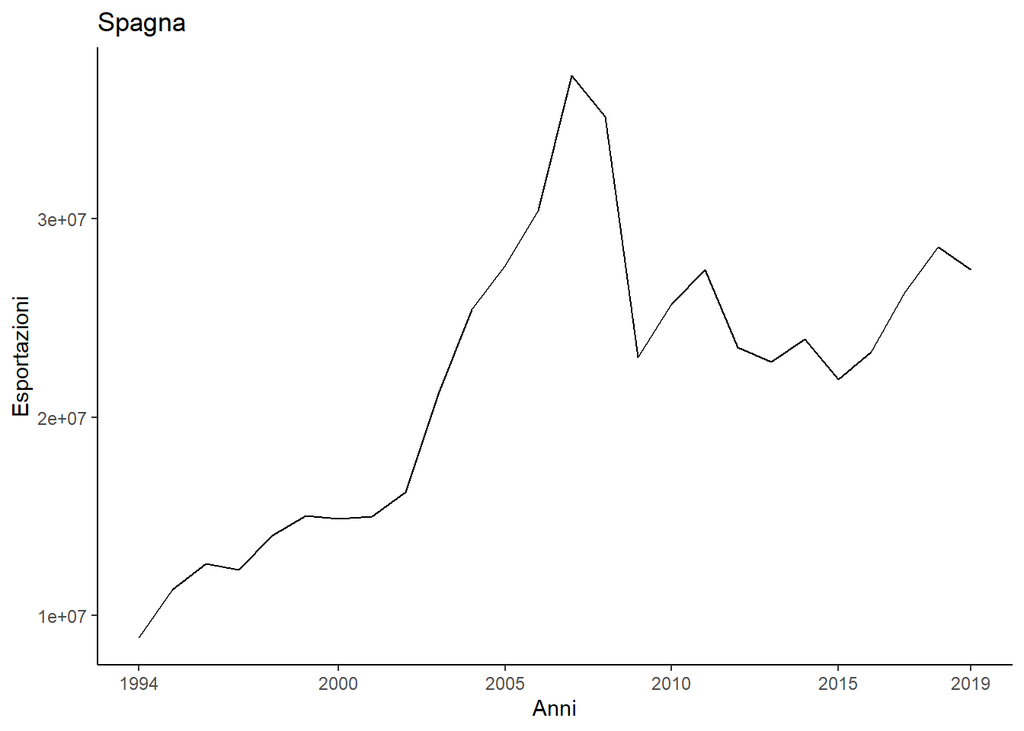

```r
ggplot(tab4, aes(x = as.numeric(Year), y = as.numeric(sub(",", ".", Export, fixed = TRUE)))) +
  geom_line(aes(group = Partner.Name), alpha = 1) +
  theme_classic() +
  xlab("Anni") +
  ylab("Esportazioni") +
  scale_x_continuous(breaks = c(1994, 2000, 2005, 2010, 2015, 2019),
                     limits = c(1994, 2019)) +
  ggtitle("Spagna")
```